# Evaluation of LC-MS contamination risk (HowDirty)

# 1 Report information

## 1.1 Data set information

**Data set:** reference_E480

**User(s):** DGZ

**Date:** 2023-07-19

**Objective:** Evaluate the risk of possible contamination with polymers and small molecules in the samples from the data set.

## 1.2 HowDirty evaluation of LC-MS results

This report was generated using *HowDirty*. This is meant to help you evaluating *How Dirty* are your samples (or system) in LC-MS analyses. The possible contaminants reported hereby could impact the quality of the results (e.g. contaminant IDs and reproducibility) and, in extreme cases, even damage the column or instruments. The raw data are previously analyzed using Skyline to extract LC-MS peaks possibly corresponding to contaminants. Then, a Risk level is assigned to each contaminant by comparing against the reference threshold (see Procedures for details). Finally, the Risk is similarly assessed at the Sample and whole Sample Set levels. These are indicative of the level of possible contamination.

**Code author:** David Gomez-Zepeda (HI-TRON)

**Version:** 0.04

# 2 Procedure

## 2.2 Warning

The algorithm used for peak picking in Skyline is simple and based only on m/z and charge (z). Thus, some true contaminant peaks (e.g. peptides) could be incorrectly assigned to contaminants (i.e. false positives). Therefore, it is recommended to also look into the Skyline file to evaluate other factors, such as patterns of contaminant groups elution across the retention time.

## 2.3 Calculations within *HowDirty*

- TICA = Total Ion Current Area
- Abundance (Normalized abundance) = TotalAreaMS1 / TICA
- TotalAbundance_ContaminantGroup = Sum (Abundance_ContaminantGroup) across all the contaminants in one ContaminantGroup for one sample
- Abundance_total = Sum (Abundance) across all the contaminants for one sample
- Contaminant-specific Risk level assessment was performed by comparing the Abundance of the possible contaminants in each one of the test samples (current data set) against thresholds previously extrapolated from a reference data set (~ 1000s runs). These thresholds are reported in results/reference_E480_report_contaminants_20230719_2205.xlsx–> ref_conta_tshd
- Sample level summary contaminant group assessment was performed by comparing the TotalAbundance_ContaminantGroup against the summed thresholds from each contaminant
- Sample level summary contaminant risk assessment was performed by comparing the Abundance_total against the sample-level quantile thresholds from the reference dataset
- These thresholds are reported in results/reference_E480_report_contaminants_20230719_2205.xlsx–> ref_conta_tshd_sample

# 3 Input

The data set contained the following:

| Variable | Count |
| --- | --- |
| Conditions | 2 |
| Samples | 1072 |
| ReplicateNames | 1072 |
| ContaminantGroups | 19 |
| Contaminants | 494 |

# 4 Summary risk evaluation (total contamination)

- Overall status: WARNING: You have some very dirty samples!!!
- Evaluation based on the total contaminant abundance

## 4.1 Global

- The piechart below shows the percentages of samples associated to each risk level
- The results were exported to results/reference_E480_report_contaminants_20230719_2205.xlsx –> risk_summ_sampleset
- RiskLevel = “1) Very Low”, “2) Low”, “3) Medium”, “4) High”, “5) Very High”, “6) No threshold in reference”

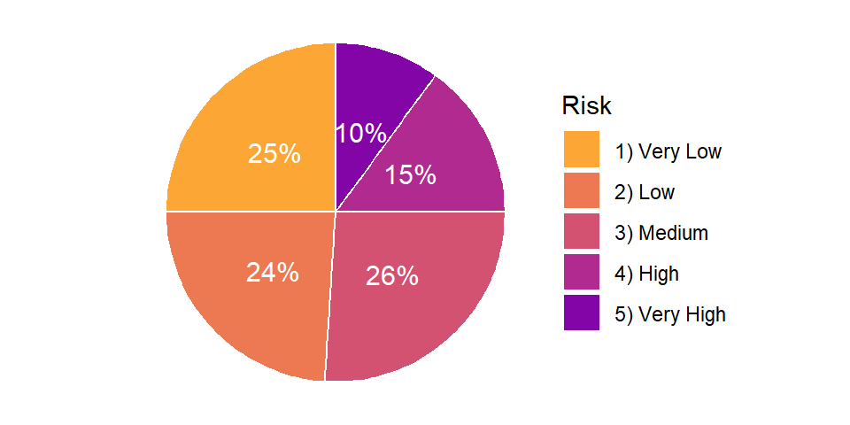

## 4.2 Conditions boxplot

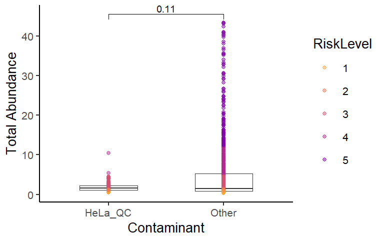

## 4.3 Sample (ordered by name)

- The table can also be found in results/reference_E480_report_contaminants_20230719_2205.xlsx –> conta_summ_sample.

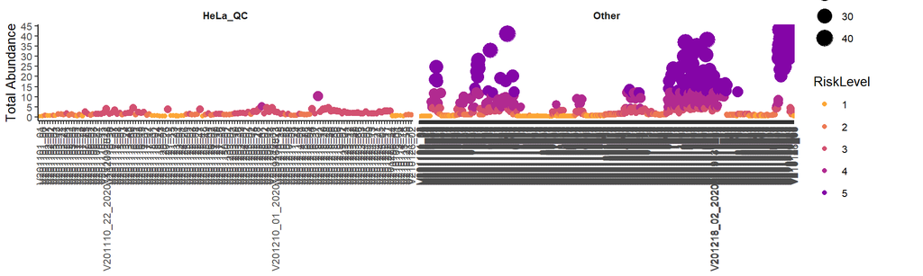

## 4.4 Sample (ordered by abundance)

- The table can also be found in results/reference_E480_report_contaminants_20230719_2205.xlsx –> conta_summ_sample.

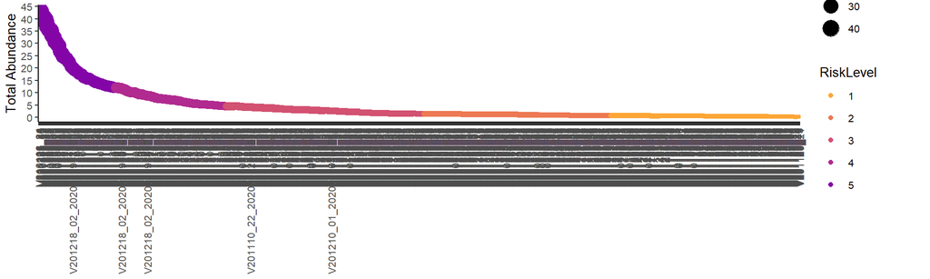

# 5 Contaminant group

## 5.1 Condition dotplot

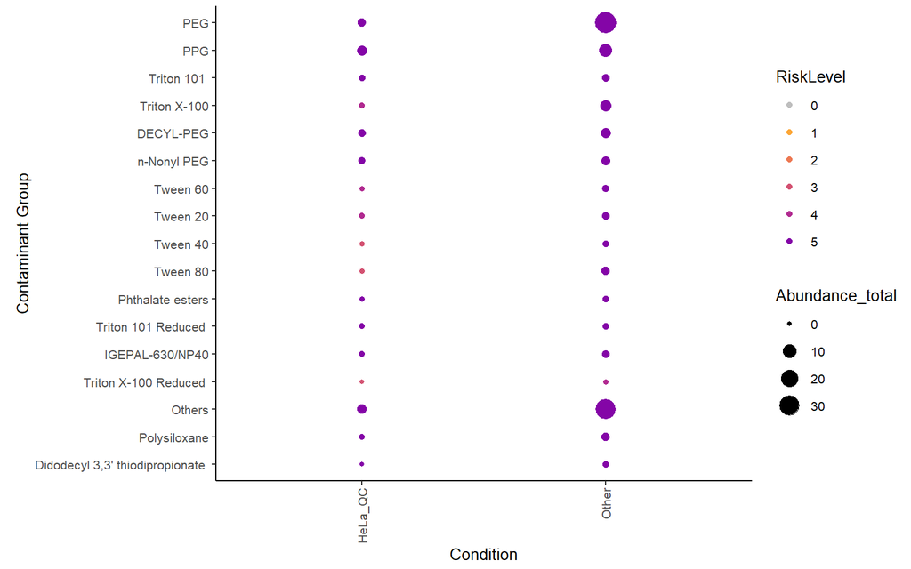

## 5.2 Sample dotplot

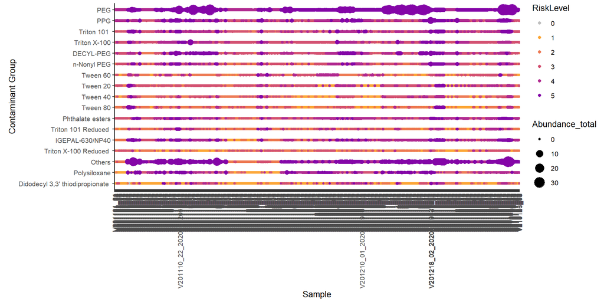

## 5.3 Sample boxplot

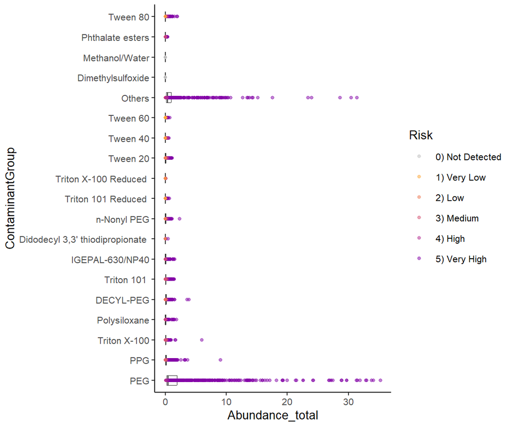

# 6 Contaminants per sample

- A summary of the Abundance per ContaminantGroup was calculated and is reported in the annexed report (results/reference_E480_report_contaminants_20230719_2205.xlsx –> conta_summ_contaminantgroup).
- The Abundance of the contaminants are reported in the plots below for all the samples in the data set.
- The Pseudochromatograms represent the Abundance in function of the RentetionTime (Apex of the peak). Those can be useful to evaluate the presence of the usual patterns of polymers, i.e. from small to larger molecules; as well as the reproducibility of the RentetionTime across replicates.

## 6.1 Abundance boxplot

### 6.1.1 PEG

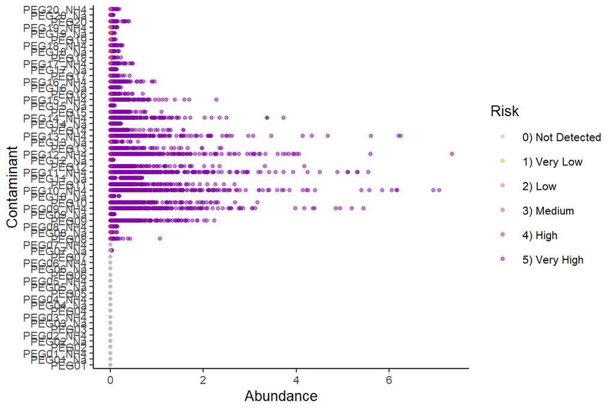

### 6.1.2 PPG

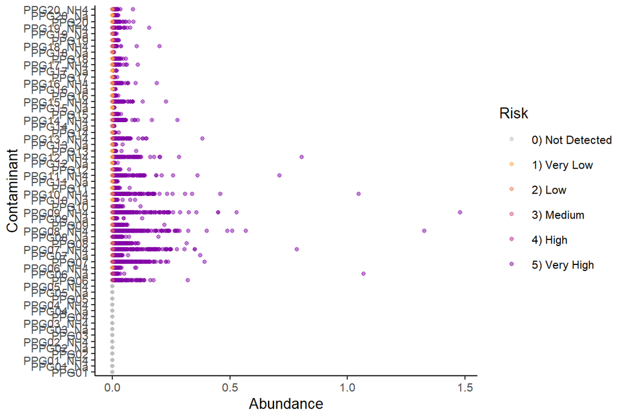

### 6.1.3 Triton X-100

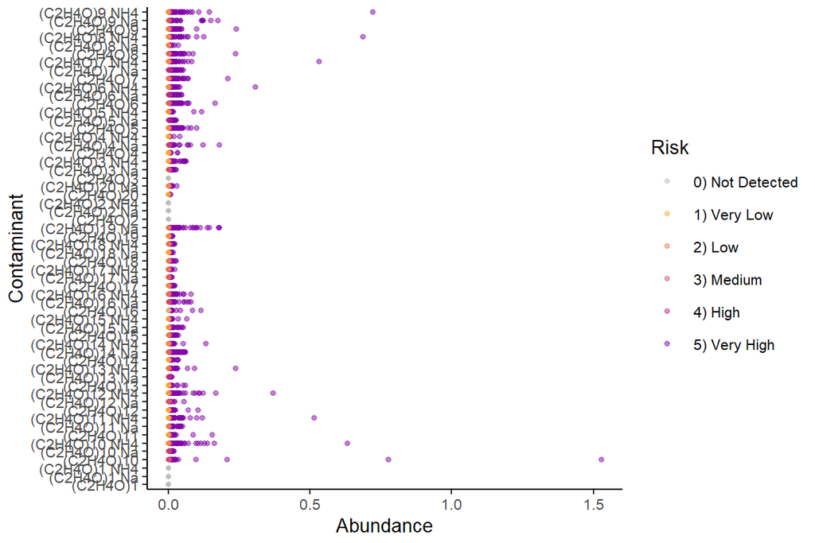

## 6.2 Pseudochromatograms (Abundance vs. RT)

### 6.2.1 PEG

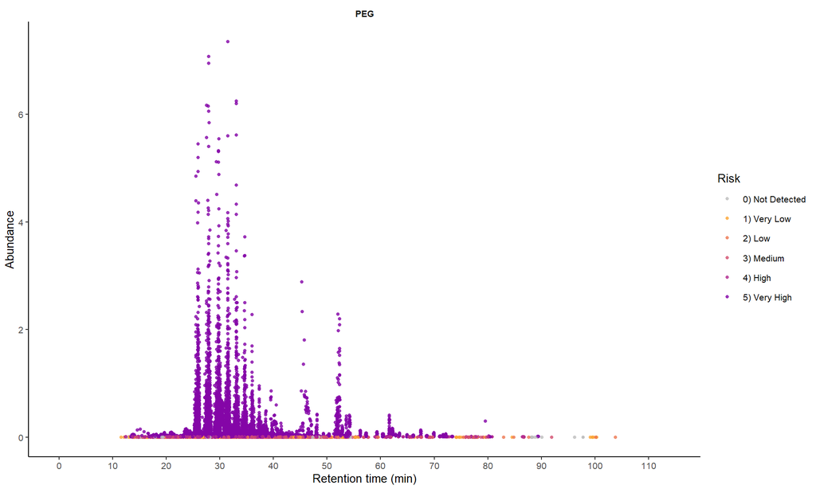

### 6.2.2 PPG

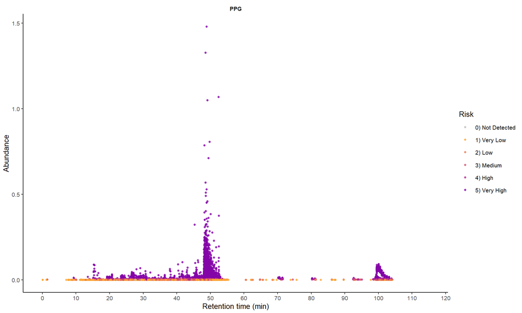

### 6.2.3 Triton X-100

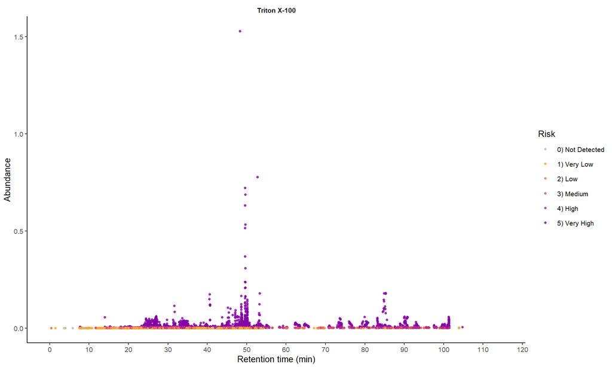

## 6.3 Table

```
## Report generated without interactive plots and tables. Please see the results in the Excel report
```

# 7 Appendix

- Result tables are exported in folder results/reference_E480_report_contaminants_20230719_2205.xlsx.

# 8 References

- Gomez-Zepeda *et al.*. HowDirty. Under preparation. (2023).
- Rardin, M. J. Rapid Assessment of Contaminants and Interferences in Mass Spectrometry Data Using Skyline. J. Am. Soc. Mass Spectrom. 29, 1327–1330 (2018).